# dsh

Autogenerated data summary from dataMaid

2019-06-05 09:45:17

# Data report overview

The dataset examined has the following dimensions:

| Feature | Result |
| --- | --- |
| Number of observations | 75 |
| Number of variables | 27 |

### Checks performed

The following variable checks were performed, depending on the data type of each variable:

|  | character | factor | labelled | haven labelled | numeric | integer | logical | Date |
| --- | --- | --- | --- | --- | --- | --- | --- | --- |
| Identify miscoded missing values | $\times$ | $\times$ | $\times$ | $\times$ | $\times$ | $\times$ |  | $\times$ |
| Identify prefixed and suffixed whitespace | $\times$ | $\times$ | $\times$ | $\times$ |  |  |  |  |
| Identify levels with < 6 obs. | $\times$ | $\times$ | $\times$ | $\times$ |  |  |  |  |
| Identify case issues | $\times$ | $\times$ | $\times$ | $\times$ |  |  |  |  |
| Identify misclassified numeric or integer variables | $\times$ | $\times$ | $\times$ | $\times$ |  |  |  |  |
| Identify outliers |  |  |  |  | $\times$ | $\times$ |  | $\times$ |

Please note that all numerical values in the following have been rounded to 2 decimals.

# Summary table

|  | Variable class | # unique values | Missing observations | Any problems? |
| --- | --- | --- | --- | --- |
| Age | numeric | 33 | 0.00 % | $\times$ |
| Sex | factor | 2 | 0.00 % |  |
| ALT | numeric | 42 | 0.00 % |  |
| AST | numeric | 18 | 0.00 % | $\times$ |
| Urea | numeric | 20 | 0.00 % |  |
| Creatinine | numeric | 10 | 0.00 % |  |
| Weight | numeric | 19 | 0.00 % | $\times$ |
| BMI | numeric | 49 | 0.00 % | $\times$ |
| FBS | numeric | 49 | 0.00 % |  |
| PPBS | numeric | 52 | 0.00 % | $\times$ |
| HbA1c | numeric | 28 | 0.00 % | $\times$ |
| Group | factor | 3 | 0.00 % |  |
| TSH | numeric | 56 | 0.00 % |  |
| T3 | numeric | 70 | 0.00 % | $\times$ |
| T4 | numeric | 45 | 0.00 % | $\times$ |
| TC | numeric | 49 | 0.00 % | $\times$ |
| LDL | numeric | 50 | 0.00 % |  |
| HDL | numeric | 28 | 0.00 % | $\times$ |
| TG | numeric | 42 | 0.00 % | $\times$ |
| VLDL | numeric | 30 | 0.00 % |  |
| LipoproteinA | numeric | 34 | 0.00 % | $\times$ |
| Smoker | character | 2 | 0.00 % |  |
| SBP | numeric | 21 | 0.00 % | $\times$ |
| DBP | numeric | 20 | 0.00 % | $\times$ |
| cursmoker | numeric | 2 | 0.00 % |  |
| trtbp | integer | 2 | 0.00 % |  |
| ASCVD | numeric | 57 | 0.00 % | $\times$ |

# Variable list

## Age

| Feature | Result |
| --- | --- |
| Variable type | numeric |
| Number of missing obs. | 0 (0 %) |
| Number of unique values | 33 |
| Median | 38 |
| 1st and 3rd quartiles | 32; 42 |
| Min. and max. | 19; 57 |

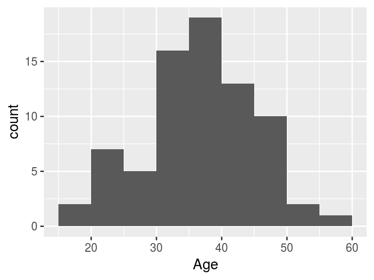

- Note that the following possible outlier values were detected: "53", "55", "57".

## Sex

| Feature | Result |
| --- | --- |
| Variable type | factor |
| Number of missing obs. | 0 (0 %) |
| Number of unique values | 2 |
| Mode | “Female” |
| Reference category | Female |

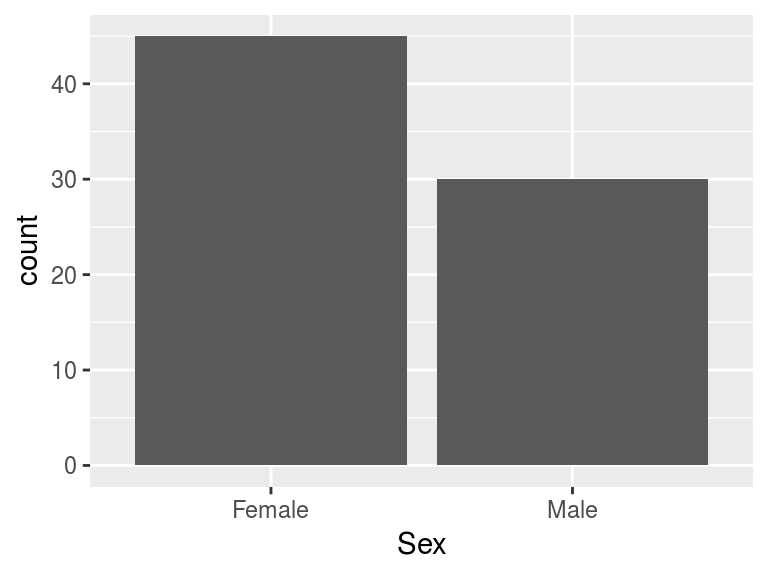

## ALT

| Feature | Result |
| --- | --- |
| Variable type | numeric |
| Number of missing obs. | 0 (0 %) |
| Number of unique values | 42 |
| Median | 49 |
| 1st and 3rd quartiles | 41; 68.5 |
| Min. and max. | 32; 95 |

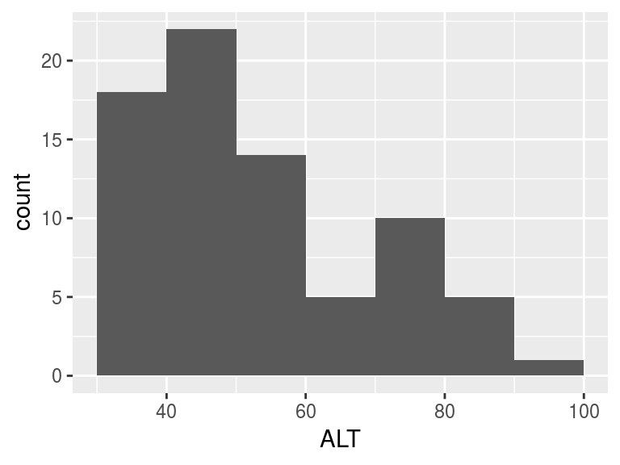

## AST

| Feature | Result |
| --- | --- |
| Variable type | numeric |
| Number of missing obs. | 0 (0 %) |
| Number of unique values | 18 |
| Median | 20 |
| 1st and 3rd quartiles | 18; 22 |
| Min. and max. | 12; 30 |

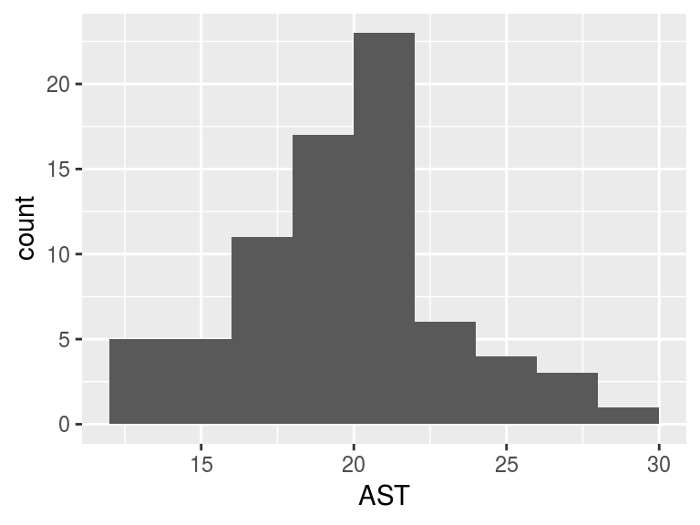

- Note that the following possible outlier values were detected: "30".

## Urea

| Feature | Result |
| --- | --- |
| Variable type | numeric |
| Number of missing obs. | 0 (0 %) |
| Number of unique values | 20 |
| Median | 29 |
| 1st and 3rd quartiles | 26; 33 |
| Min. and max. | 21; 42 |

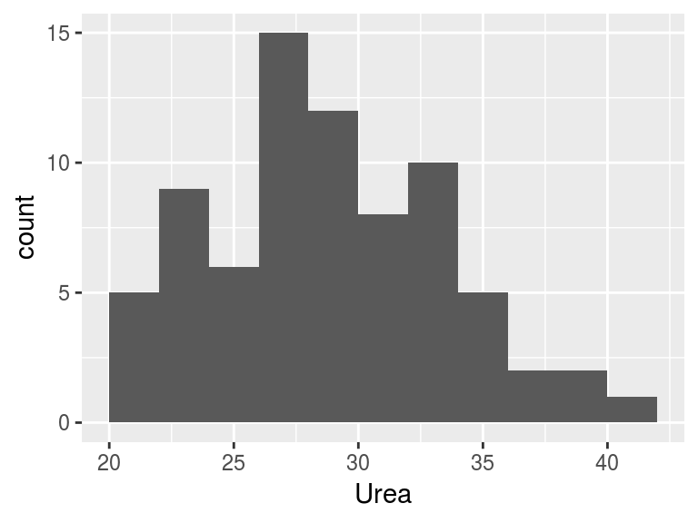

## Creatinine

| Feature | Result |
| --- | --- |
| Variable type | numeric |
| Number of missing obs. | 0 (0 %) |
| Number of unique values | 10 |
| Median | 1.3 |
| 1st and 3rd quartiles | 1.15; 1.4 |
| Min. and max. | 0.8; 1.7 |

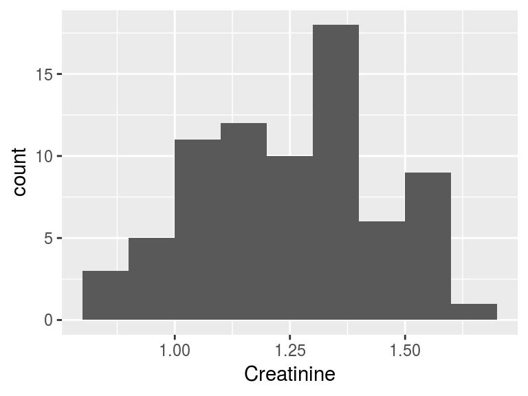

## Weight

| Feature | Result |
| --- | --- |
| Variable type | numeric |
| Number of missing obs. | 0 (0 %) |
| Number of unique values | 19 |
| Median | 63 |
| 1st and 3rd quartiles | 60; 67 |
| Min. and max. | 56; 77 |

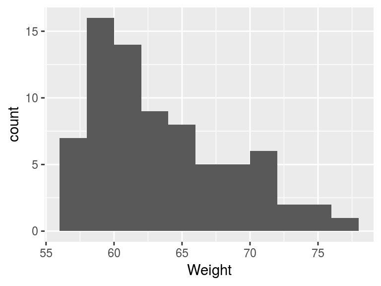

- Note that the following possible outlier values were detected: "56".

## BMI

| Feature | Result |
| --- | --- |
| Variable type | numeric |
| Number of missing obs. | 0 (0 %) |
| Number of unique values | 49 |
| Median | 26.7 |
| 1st and 3rd quartiles | 25; 27.75 |
| Min. and max. | 22.2; 32.2 |

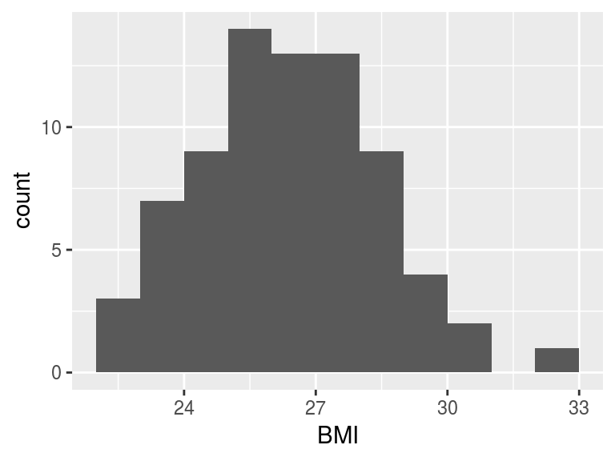

- Note that the following possible outlier values were detected: "29.9", "30.3", "30.6", "32.2".

## FBS

| Feature | Result |
| --- | --- |
| Variable type | numeric |
| Number of missing obs. | 0 (0 %) |
| Number of unique values | 49 |
| Median | 171 |
| 1st and 3rd quartiles | 157.5; 183 |
| Min. and max. | 133; 216 |

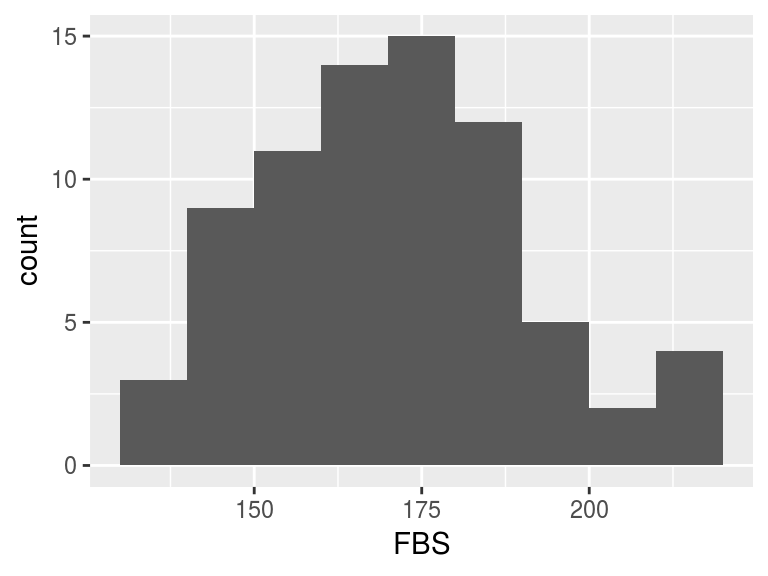

## PPBS

| Feature | Result |
| --- | --- |
| Variable type | numeric |
| Number of missing obs. | 0 (0 %) |
| Number of unique values | 52 |
| Median | 215 |
| 1st and 3rd quartiles | 203.5; 238 |
| Min. and max. | 181; 317 |

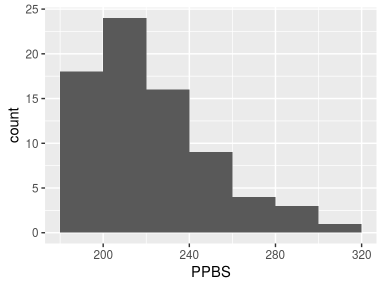

- Note that the following possible outlier values were detected: "181", "182", "183", "184", "185".

## HbA1c

| Feature | Result |
| --- | --- |
| Variable type | numeric |
| Number of missing obs. | 0 (0 %) |
| Number of unique values | 28 |
| Median | 8 |
| 1st and 3rd quartiles | 7.5; 8.4 |
| Min. and max. | 6.5; 9.8 |

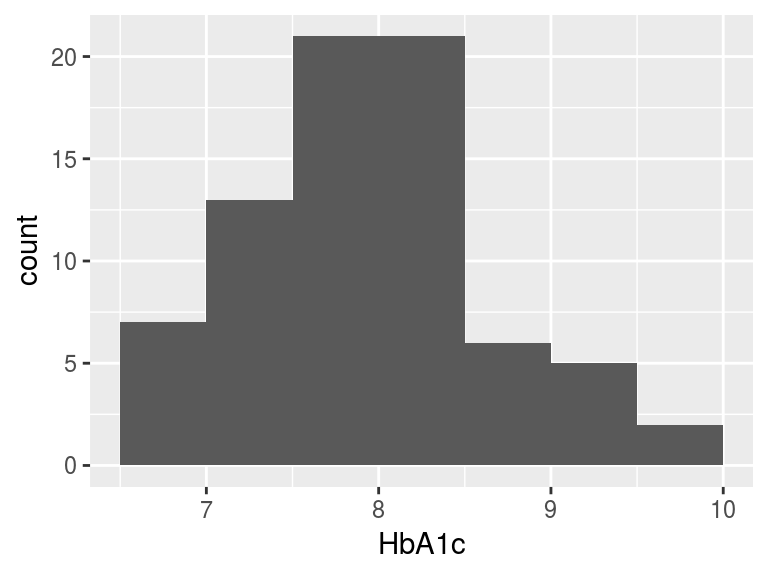

- Note that the following possible outlier values were detected: "9.8".

## Group

| Feature | Result |
| --- | --- |
| Variable type | factor |
| Number of missing obs. | 0 (0 %) |
| Number of unique values | 3 |
| Mode | “DM” |
| Reference category | DM |

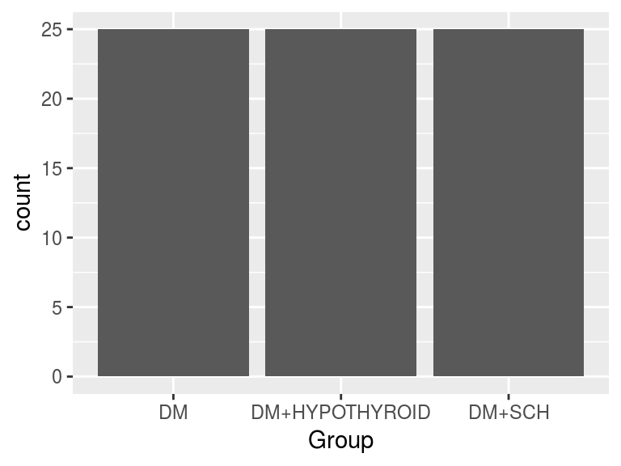

## TSH

| Feature | Result |
| --- | --- |
| Variable type | numeric |
| Number of missing obs. | 0 (0 %) |
| Number of unique values | 56 |
| Median | 8.3 |
| 1st and 3rd quartiles | 3.3; 17.45 |
| Min. and max. | 1.4; 27.6 |

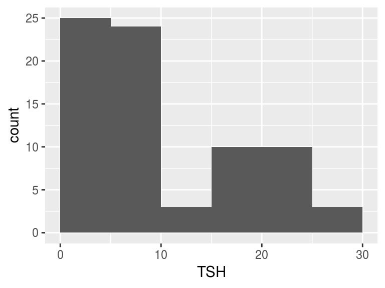

## T3

| Feature | Result |
| --- | --- |
| Variable type | numeric |
| Number of missing obs. | 0 (0 %) |
| Number of unique values | 70 |
| Median | 108.6 |
| 1st and 3rd quartiles | 42.75; 119.85 |
| Min. and max. | 23.2; 151.2 |

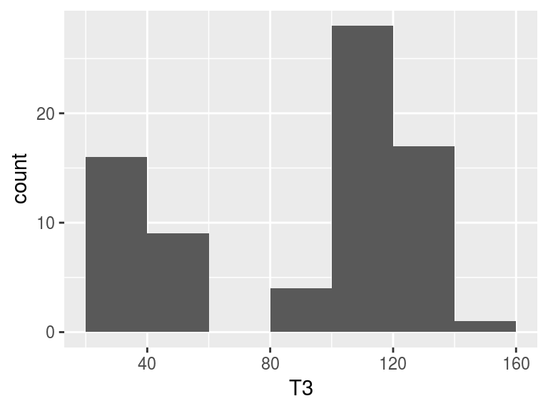

- Note that the following possible outlier values were detected: "132.6", "133.6", "134.3", "136.2", "136.5", "151.2".

## T4

| Feature | Result |
| --- | --- |
| Variable type | numeric |
| Number of missing obs. | 0 (0 %) |
| Number of unique values | 45 |
| Median | 7.1 |
| 1st and 3rd quartiles | 3.1; 8.3 |
| Min. and max. | 0.5; 10.4 |

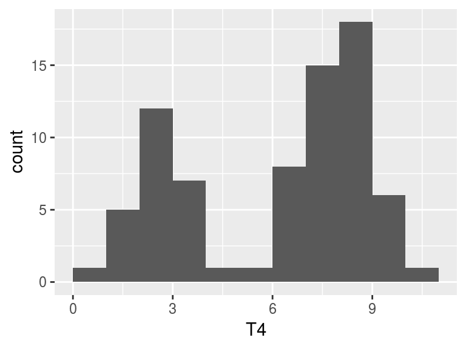

- Note that the following possible outlier values were detected: "9.7", "9.9", "10.4".

## TC

| Feature | Result |
| --- | --- |
| Variable type | numeric |
| Number of missing obs. | 0 (0 %) |
| Number of unique values | 49 |
| Median | 264 |
| 1st and 3rd quartiles | 245; 302.5 |
| Min. and max. | 222; 344 |

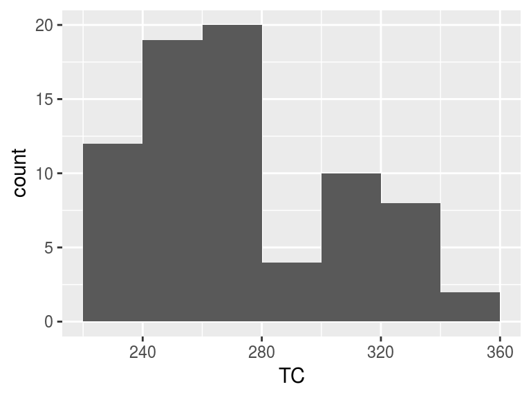

- Note that the following possible outlier values were detected: "222".

## LDL

| Feature | Result |
| --- | --- |
| Variable type | numeric |
| Number of missing obs. | 0 (0 %) |
| Number of unique values | 50 |
| Median | 186 |
| 1st and 3rd quartiles | 163; 229 |
| Min. and max. | 150; 280 |

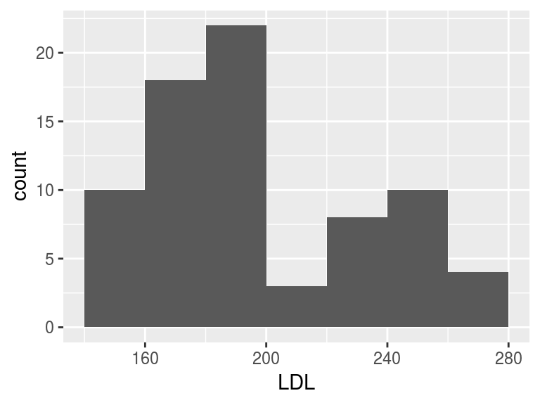

## HDL

| Feature | Result |
| --- | --- |
| Variable type | numeric |
| Number of missing obs. | 0 (0 %) |
| Number of unique values | 28 |
| Median | 34 |
| 1st and 3rd quartiles | 27.5; 38 |
| Min. and max. | 12; 47 |

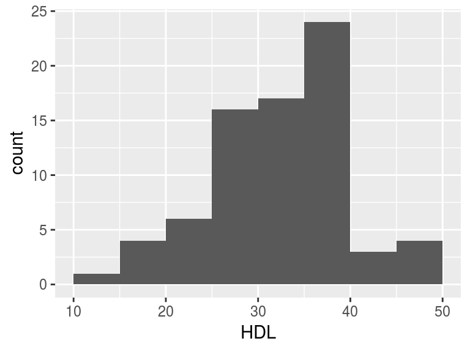

- Note that the following possible outlier values were detected: "47".

## TG

| Feature | Result |
| --- | --- |
| Variable type | numeric |
| Number of missing obs. | 0 (0 %) |
| Number of unique values | 42 |
| Median | 216 |
| 1st and 3rd quartiles | 207.5; 227.5 |
| Min. and max. | 187; 269 |

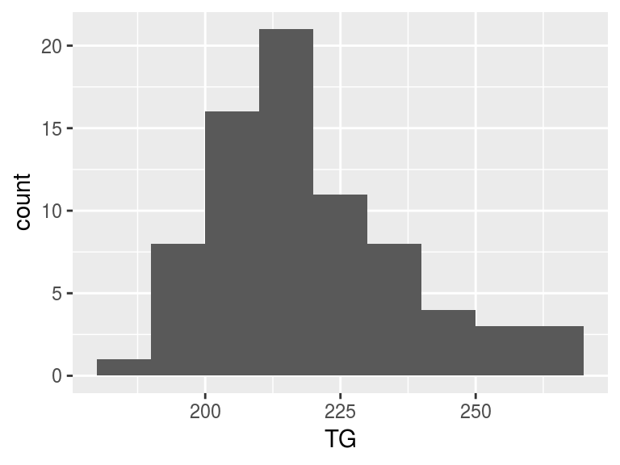

- Note that the following possible outlier values were detected: "187", "192".

## VLDL

| Feature | Result |
| --- | --- |
| Variable type | numeric |
| Number of missing obs. | 0 (0 %) |
| Number of unique values | 30 |
| Median | 42 |
| 1st and 3rd quartiles | 35; 48.5 |
| Min. and max. | 23; 61 |

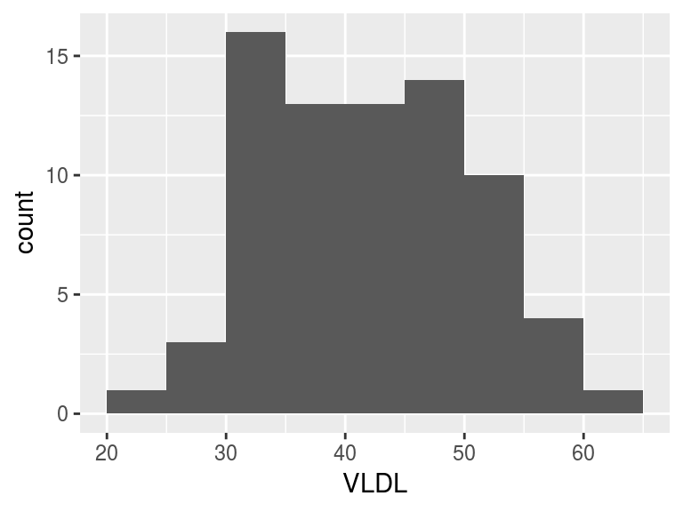

## LipoproteinA

| Feature | Result |
| --- | --- |
| Variable type | numeric |
| Number of missing obs. | 0 (0 %) |
| Number of unique values | 34 |
| Median | 25 |
| 1st and 3rd quartiles | 19; 33.5 |
| Min. and max. | 5; 56 |

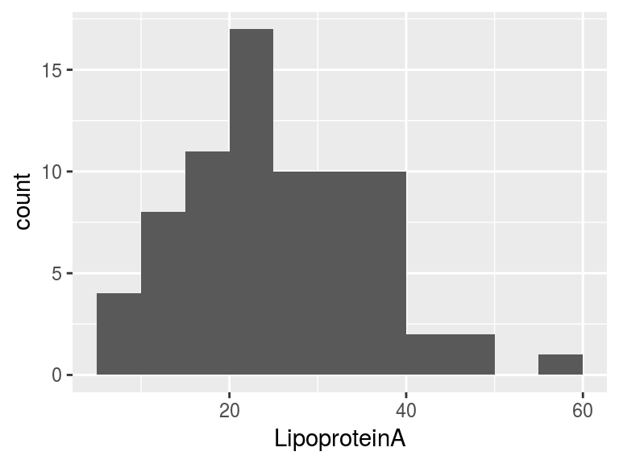

- Note that the following possible outlier values were detected: "5".

## Smoker

| Feature | Result |
| --- | --- |
| Variable type | character |
| Number of missing obs. | 0 (0 %) |
| Number of unique values | 2 |
| Mode | “Non-smoker” |

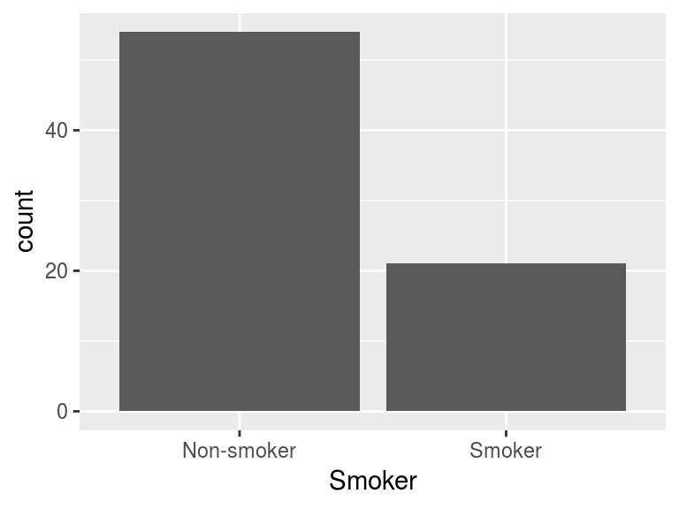

## SBP

| Feature | Result |
| --- | --- |
| Variable type | numeric |
| Number of missing obs. | 0 (0 %) |
| Number of unique values | 21 |
| Median | 144 |
| 1st and 3rd quartiles | 136; 151 |
| Min. and max. | 114; 164 |

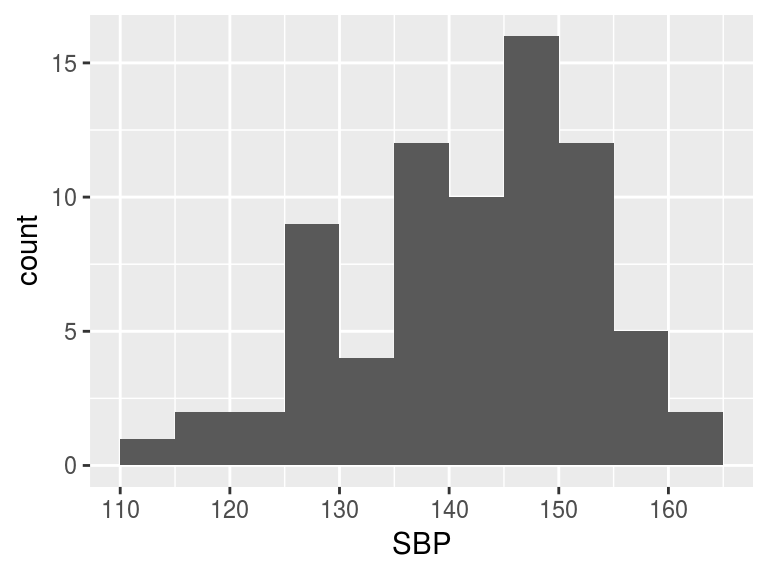

- Note that the following possible outlier values were detected: "162", "164".

## DBP

| Feature | Result |
| --- | --- |
| Variable type | numeric |
| Number of missing obs. | 0 (0 %) |
| Number of unique values | 20 |
| Median | 90 |
| 1st and 3rd quartiles | 84; 96 |
| Min. and max. | 64; 112 |

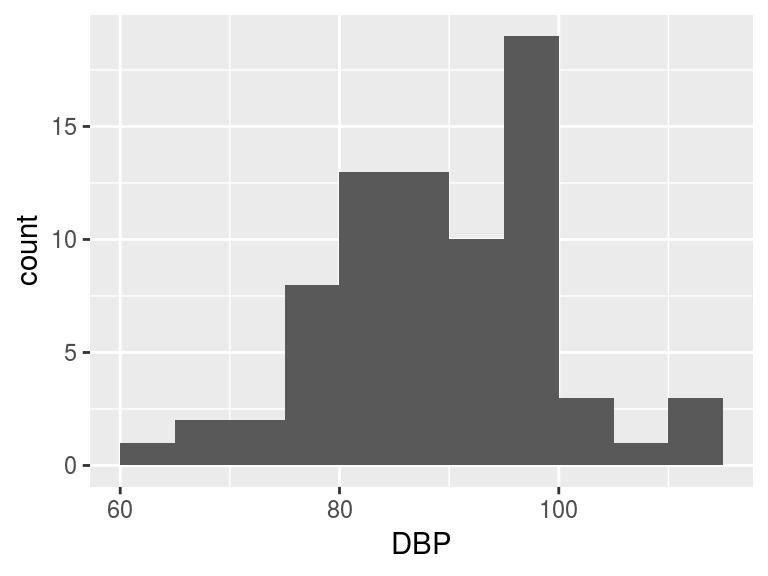

- Note that the following possible outlier values were detected: "64".

## cursmoker

- Note that this variable is treated as a factor variable below, as it only takes a few unique values.

| Feature | Result |
| --- | --- |
| Variable type | numeric |
| Number of missing obs. | 0 (0 %) |
| Number of unique values | 2 |
| Mode | “0” |
| Reference category | 0 |

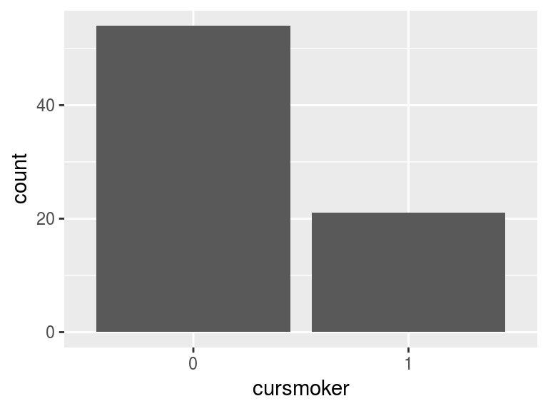

## trtbp

- Note that this variable is treated as a factor variable below, as it only takes a few unique values.

| Feature | Result |
| --- | --- |
| Variable type | integer |
| Number of missing obs. | 0 (0 %) |
| Number of unique values | 2 |
| Mode | “0” |
| Reference category | 0 |

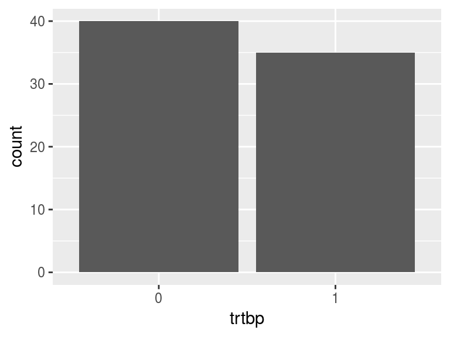

## ASCVD

| Feature | Result |
| --- | --- |
| Variable type | numeric |
| Number of missing obs. | 0 (0 %) |
| Number of unique values | 57 |
| Median | 4.3 |
| 1st and 3rd quartiles | 2.3; 11.6 |
| Min. and max. | 0.5; 93.7 |

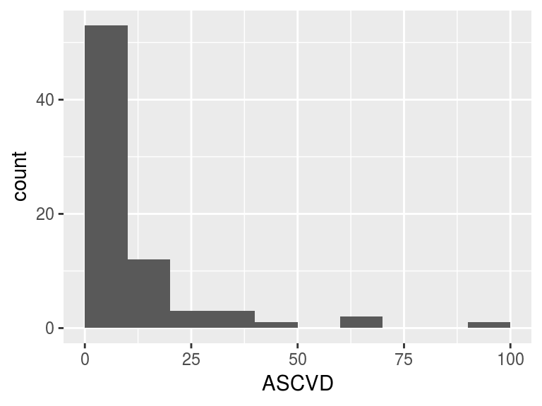

- Note that the following possible outlier values were detected: "0.5", "0.6", "0.8".

Report generation information:

- Created by anupamsingh81 (username: `anupam`).
- Report creation time: Wed Jun 05 2019 09:45:18
- Report was run from directory: `/home/anupam/Documents/hypothyroid`
- dataMaid v1.2.0 [Pkg: 2018-10-03 from CRAN (R 3.4.3)]
- R version 3.5.3 (2019-03-11).
- Platform: x86_64-pc-linux-gnu (64-bit)(Ubuntu 16.04.5 LTS).
- Function call: `makeDataReport(data = dsh, render = FALSE, replace = TRUE, openResult = FALSE)`